# act_report

## Report: act_report

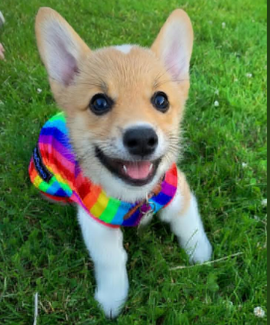

**This report is the summary of Data analysis of the WeRateDog Twitter data archive. It discusses the visualization and insights produced from the data wrangling processes.**

Data visualization and insightful analysis is the sorta fun part of data analysis. After long hours with data gathering, assessing and cleaning, all these are put together and make meaningful by the visualizations and insights drawn. See my `wrangle_act` files for detailed journey through the data wrangling processes, quality issues, tidiness issues and how they were fixed.

In this Udacity project visualizations, packages and functions where used to answer insightful questions about the dataset. Having stored the dataset as `twitter_archive_master.csv`, the following steps details my visualization processes.

First, as a rule of thumb, i imported the neccessay packages for this visualizations. knowing that i'll be making plots, `matplotlib`, `seaborn` and the ever present `pandas` were imported.

```python
import pandas as pd
import matplotlib.pyplot as plt
import seaborn as sns
```

Next, i read the `twitter_archive_master.csv` into a pandas dataframe called `df` and render a copy of this (`df_clean`) which will be used throughout the visualization process.

```python
df = pd.read_csv("twitter_archive_master.csv")
df_clean = df.copy()
```

## Insights:

While working on the data wrangling, with the data available i've always wanted to explore the full description of the dataset. with a special interest in `retweet_count`, `favorite_count`. Want to know how this columns look will describe statistically? lets see;

1. **Explore data description of the dataset**

```python
df_clean.describe()
```

|  | tweet_id | rating | img_num | p1_conf | p2_conf | p3_conf | retweet_count | favorite_count | followers_count | listed_count |
| --- | --- | --- | --- | --- | --- | --- | --- | --- | --- | --- |
| count | 1.994000e+03 | 1994.000000 | 1994.000000 | 1994.000000 | 1.994000e+03 | 1.994000e+03 | 1994.000000 | 1994.000000 | 1.994000e+03 | 1994.000000 |
| mean | 7.358508e+17 | 1.169249 | 1.203109 | 0.593941 | 1.344195e-01 | 6.024848e-02 | 2766.753260 | 8895.725677 | 3.200946e+06 | 2800.559679 |
| std | 6.747816e+16 | 4.067071 | 0.560777 | 0.271954 | 1.006807e-01 | 5.089067e-02 | 4674.698447 | 12213.193181 | 4.478196e+01 | 11.124380 |
| min | 6.660209e+17 | 0.000000 | 1.000000 | 0.044333 | 1.011300e-08 | 1.740170e-10 | 16.000000 | 81.000000 | 3.200799e+06 | 2724.000000 |
| 25% | 6.758475e+17 | 1.000000 | 1.000000 | 0.362857 | 5.393987e-02 | 1.619283e-02 | 624.750000 | 1982.000000 | 3.200901e+06 | 2788.000000 |
| 50% | 7.084748e+17 | 1.100000 | 1.000000 | 0.587635 | 1.174550e-01 | 4.950530e-02 | 1359.500000 | 4136.000000 | 3.200947e+06 | 2803.000000 |
| 75% | 7.877873e+17 | 1.200000 | 1.000000 | 0.846285 | 1.951377e-01 | 9.159438e-02 | 3220.000000 | 11308.000000 | 3.201002e+06 | 2812.000000 |
| max | 8.924206e+17 | 177.600000 | 4.000000 | 1.000000 | 4.880140e-01 | 2.734190e-01 | 79515.000000 | 132810.000000 | 3.201018e+06 | 2846.000000 |

**Awesome!** This displays the whole columns with integer as datatype. zeroing in on the columns: `img_num` still ranges form 1 (minimum) to 4 (maximum), maybe cause as at when data was gathered, maximum image per post was 4. `retweet_count` and `favorite_count`: now this's interesting. the count row dispalces the total count of each column and the `mean` row displaced the average. it can be seen that based on this data, tweets are more likely to get a favorite than a retweet. Tweeps just perfer to hit the `like button` than the `retweet button`.

Moving on to our next idea.

### Insight #2:

With the `day` column data wont it be interesting to find out which day of the week gets the most tweets from Tweeps? My guess is that it is, so let's find out.

1. **Which day has the most Tweet?**

```python
df_clean_d = df_clean.day.value_counts()
df_clean_d
```

```
Mon    327
Wed    297
Tue    295
Thu    284
Fri    283
Sun    256
Sat    252
Name: day, dtype: int64
```

Monday? Interesting, Let's visualize this one a chart; say pie

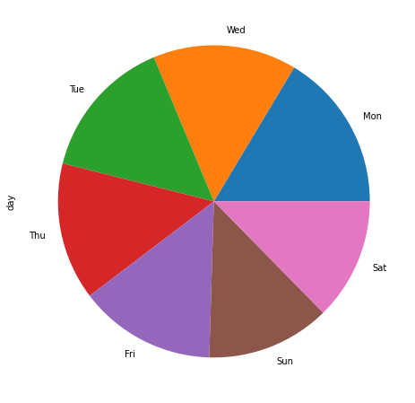

```python
df_clean_d.plot(kind='pie', figsize=(8,8));
```

**Awesome**. Monday followed very closely by Wednesdays are the days with the most tweets from Tweeps (Twitter users). Why Monday though?

### Insight #3:

It's one thing to make a post and another to engage with other post or actaully use the app. Though Monday is the day with the most tweets, let's see the day with the most tweet engagements. This can be arrived at by adding `retweet_count` and `favorite_count` to the picture. Hmmm, let's see;

```python
df_clean_drf=df_clean.groupby(["day"], as_index=False)["retweet_count", "favorite_count"].sum()
df_clean_drf.sort_values(by=["retweet_count"], ascending = False).head(7)
```

|  | day | retweet_count | favorite_count |
| --- | --- | --- | --- |
| 6 | Wed | 917619 | 2959721 |
| 1 | Mon | 862138 | 2780551 |
| 5 | Tue | 802284 | 2680197 |
| 0 | Fri | 787992 | 2461795 |
| 2 | Sat | 747924 | 2262207 |
| 4 | Thu | 717374 | 2368337 |
| 3 | Sun | 681575 | 2225269 |

Okay, the verdict is here. Though Monday is the day with the most Tweets, Wednesday stands out as the day with the most engagement; in terms of favorites and retweets.

Makes sense, right? i mean who wants to engage with tweets on a busy Monday.

So, these are the insights and visualizations performed on the cleaned twitter_archive dataset.